# Heritage Validation Part 2

```r
library(tidyverse)
library(data.table)
library(broom)
library(car)
library(knitr)
library(ggpubr)
theme_set(theme_bw())
```

> FOR THIS SECTION, only use those HERITAGE subjects who have VO2max and proteomic data measured at baseline and after exercise training (**N=643**)

### Update 03/18/2024 : Scale protein score.

```r
mean_pre_score_unscaled <- mean(protein_score_pre$proteomic_score_pre)
sd_pre_score_unscaled <- sd(protein_score_pre$proteomic_score_pre)

protein_score_pre_scaled =
  protein_score_pre %>%
  transmute(PID, proteomic_score_pre_scaled = (proteomic_score_pre - mean_pre_score_unscaled) / sd_pre_score_unscaled)

protein_score_post_scaled =
  protein_score_post %>%
  transmute(PID, proteomic_score_post_scaled = (proteomic_score_post - mean_pre_score_unscaled) / sd_pre_score_unscaled)

protein_score_prepost_scaled  =
  protein_score_pre_scaled %>%
  inner_join(protein_score_post_scaled, by = "PID")
```

```r
her_pheno_lt = her_pheno_raw %>%
  mutate(SEX  = case_when(SEX ==  1 ~ "Male", SEX == 2 ~ "Female", TRUE ~ NA_character_),
         RACE = case_when(RACE == 1 ~ "Black", RACE == 2 ~ "Caucasian", TRUE ~ NA_character_),
         GEN  = case_when(GEN ==  1 ~ "Parent", GEN == 2 ~ "Offspring", TRUE ~ NA_character_),
         B_VO2MX_B_WT18 = B_VO2MX/B_WT18,
         P_VO2MX_P_WT18 = P_VO2MX/P_WT18,
         D_VO2MX_ML_KG_MIN = P_VO2MX/P_WT18 - B_VO2MX/B_WT18
         ) %>%
  select(PID, SEX, RACE, AGE, GEN, B_BMI, B_VO2MX, D_VO2MX, B_WT18, D_WT18, P_VO2MX, P_WT18, B_VO2MX_B_WT18, P_VO2MX_P_WT18, D_VO2MX_ML_KG_MIN) %>%
  filter(!is.na(B_VO2MX), !is.na(B_BMI), !is.na(AGE), !is.na(SEX), !is.na(B_WT18)) %>%  #,
  mutate(SEX = factor(SEX, levels = c("Male", "Female")))

part_2_df = her_pheno_lt %>% inner_join(protein_score_prepost, by = "PID")

part_2_df_scaled = her_pheno_lt %>% inner_join(protein_score_prepost_scaled, by = "PID")
```

### 1. Show box plot with pre and post-training, report t-test

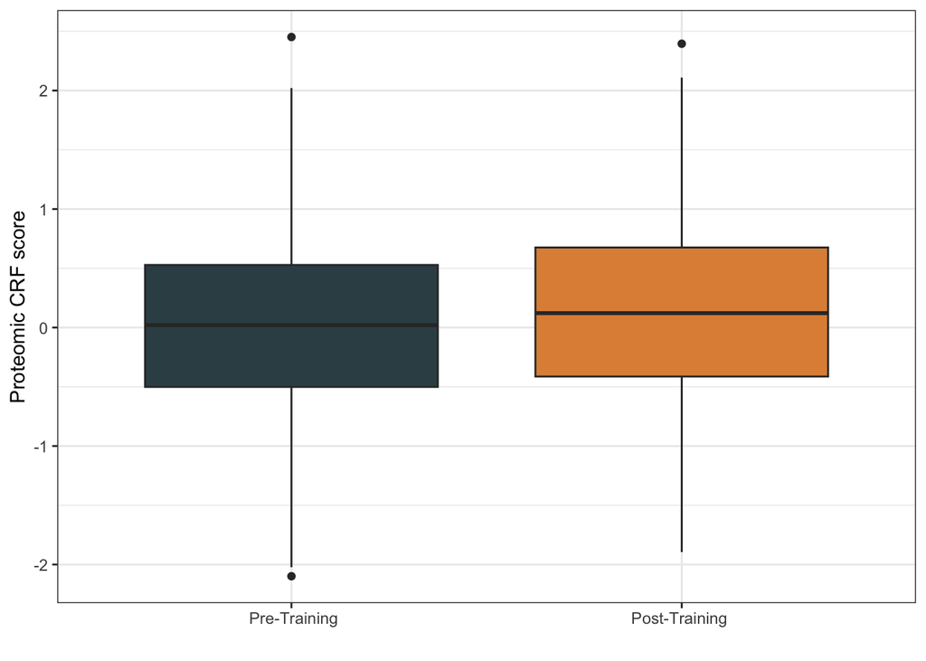

```r
## Box Plot
protein_score_prepost %>%
  rename(" Pre-Training" = proteomic_score_pre, "Post-Training " = proteomic_score_post) %>%
  pivot_longer(-PID, values_to = "Proteomic CRF score") %>%
  ggplot(aes(x = name, y = `Proteomic CRF score`, fill = name)) +
  geom_boxplot() +
  theme(legend.position = "none") +
  labs(x = "")
```

##### Compare Scaled Score

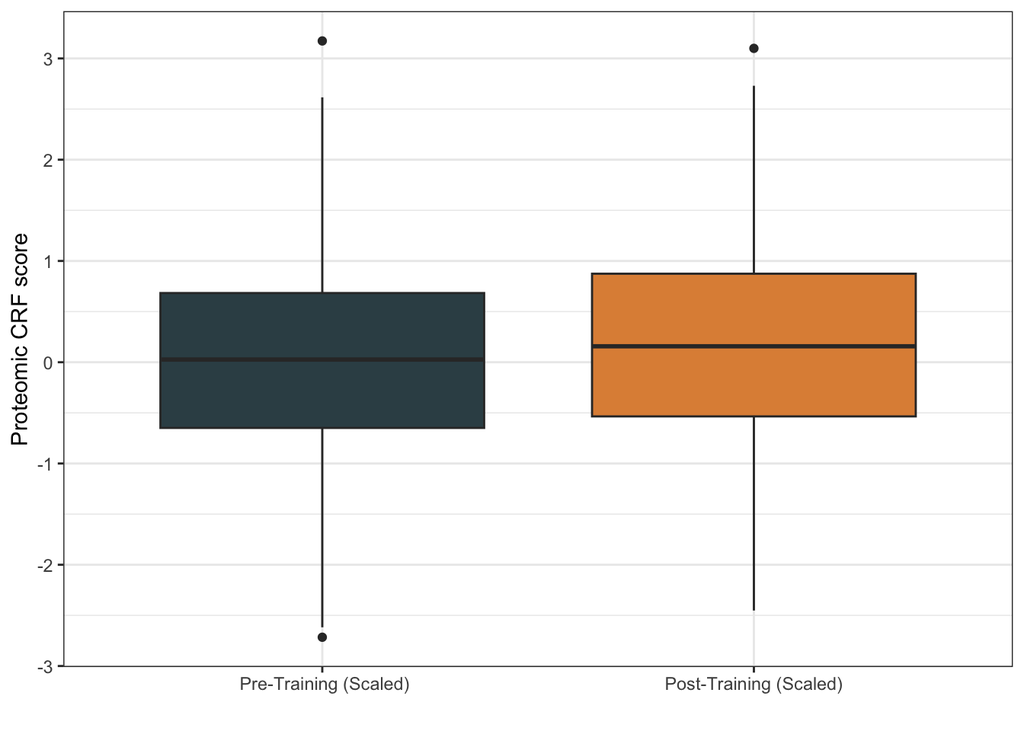

```r
protein_score_prepost_scaled %>%
  rename(" Pre-Training (Scaled)" = proteomic_score_pre_scaled, "Post-Training (Scaled)" = proteomic_score_post_scaled) %>%
  pivot_longer(-PID, values_to = "Proteomic CRF score") %>%
  ggplot(aes(x = name, y = `Proteomic CRF score`, fill = name)) +
  geom_boxplot() +
  theme(legend.position = "none") +
  labs(x = "")
```

##### Subsquence analysis are using Scaled Score

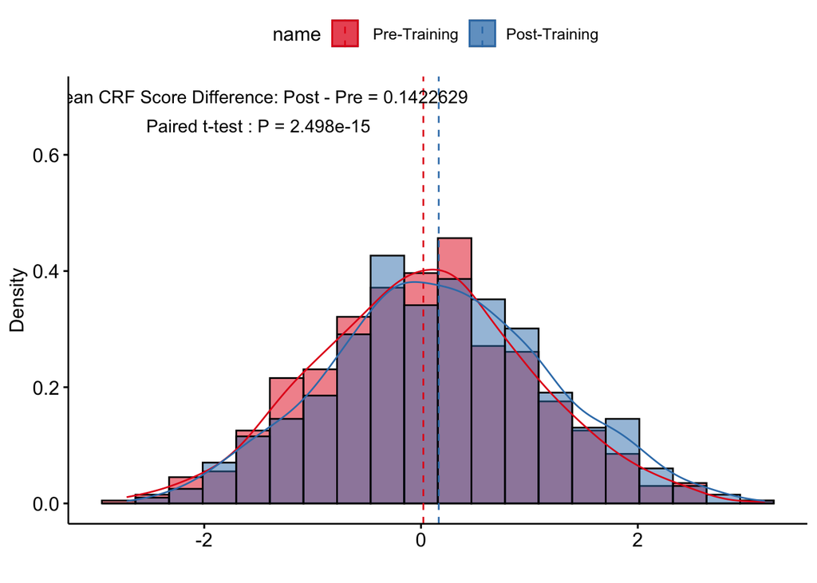

```r
Proteomic_CRF_score_df_long = protein_score_prepost_scaled %>%
  rename(" Pre-Training" = proteomic_score_pre_scaled, "Post-Training " = proteomic_score_post_scaled) %>%
  pivot_longer(-PID, values_to = "Proteomic_CRF_score") %>%
  setDT()

CRF_pre_mean  = Proteomic_CRF_score_df_long[name == " Pre-Training",  Proteomic_CRF_score] %>% mean(na.rm = T) %>% round(digits = 2)
CRF_post_mean = Proteomic_CRF_score_df_long[name == "Post-Training ", Proteomic_CRF_score] %>% mean(na.rm = T) %>% round(digits = 2)

Proteomic_CRF_score_df_long %>%
  gghistogram(
  x = "Proteomic_CRF_score",
  y = "..density..",
  add = "mean",
  fill = "name",
  palette = "Set1",
  add_density = TRUE,
  bins = 20) +
  labs(x = "", y = "Density") +
  annotate("text", x = -1.5, y = 0.7, label =  paste0("Mean CRF Score Difference: Post - Pre = 0.1422629")) +
  annotate("text", x = -1.5, y = 0.65, label =  paste0("Paired t-test : P = 2.498e-15"))
```

```r
  # annotate("text", x = CRF_pre_mean, y = 0.65, label = CRF_pre_mean) +
  # annotate("text", x = CRF_post_mean, y = 0.7, label = CRF_post_mean)

t.test(
  protein_score_prepost_scaled$proteomic_score_post_scaled,
  protein_score_prepost_scaled$proteomic_score_pre_scaled,
  paired = T
  )
```

```
    Paired t-test

data:  protein_score_prepost_scaled$proteomic_score_post_scaled and protein_score_prepost_scaled$proteomic_score_pre_scaled
t = 8.114, df = 642, p-value = 2.498e-15
alternative hypothesis: true mean difference is not equal to 0
95 percent confidence interval:
 0.1078339 0.1766919
sample estimates:
mean difference
      0.1422629
```

### 2. Is the baseline proteomic score predictive of training response?

###### a. post training VO2max (P_VO2/WT_18) ~ pre training VO2 (B_VO2/WT_18) + pre training protein score + covariates (age/sex/race/+/-BMI)

```r
part_2_df_scaled %>%
  lm(P_VO2MX_P_WT18 ~ B_VO2MX_B_WT18 + proteomic_score_pre_scaled + AGE + SEX + RACE, data =.) %>%
  tidy() %>%
  mutate_if(is.numeric, signif, 3) %>% kable()
```

| term | estimate | std.error | statistic | p.value |
| --- | --- | --- | --- | --- |
| (Intercept) | 9.2200 | 1.0400 | 8.83 | 0.00e+00 |
| B_VO2MX_B_WT18 | 0.9110 | 0.0236 | 38.70 | 0.00e+00 |
| proteomic_score_pre_scaled | 0.5930 | 0.1730 | 3.43 | 6.43e-04 |
| AGE | -0.0451 | 0.0115 | -3.93 | 9.63e-05 |
| SEXFemale | -0.4500 | 0.3030 | -1.49 | 1.38e-01 |
| RACECaucasian | 1.0400 | 0.2710 | 3.82 | 1.44e-04 |

```r
part_2_df_scaled %>%
  lm(P_VO2MX_P_WT18 ~ B_VO2MX_B_WT18 + proteomic_score_pre_scaled + AGE + SEX + RACE, data =.) %>%
  vif() %>% kable()
```

|  | x |
| --- | --- |
| B_VO2MX_B_WT18 | 3.584519 |
| proteomic_score_pre_scaled | 2.374540 |
| AGE | 1.951167 |
| SEX | 1.843997 |
| RACE | 1.345960 |

```r
part_2_df_scaled %>%
  lm(P_VO2MX_P_WT18 ~ B_VO2MX_B_WT18 + proteomic_score_pre_scaled + AGE + SEX + RACE + B_BMI, data=.) %>%
  tidy() %>%
  mutate_if(is.numeric, signif, 3) %>% kable()
```

| term | estimate | std.error | statistic | p.value |
| --- | --- | --- | --- | --- |
| (Intercept) | 17.6000 | 1.6600 | 10.60 | 0.00e+00 |
| B_VO2MX_B_WT18 | 0.8340 | 0.0258 | 32.30 | 0.00e+00 |
| proteomic_score_pre_scaled | 0.3000 | 0.1740 | 1.73 | 8.48e-02 |
| AGE | -0.0592 | 0.0114 | -5.21 | 3.00e-07 |
| SEXFemale | -1.5600 | 0.3420 | -4.58 | 5.60e-06 |
| RACECaucasian | 1.0300 | 0.2620 | 3.92 | 9.73e-05 |
| B_BMI | -0.1840 | 0.0287 | -6.40 | 0.00e+00 |

```r
part_2_df_scaled %>%
  lm(P_VO2MX_P_WT18 ~ B_VO2MX_B_WT18 + proteomic_score_pre_scaled + AGE + SEX + RACE + B_BMI, data=.) %>%
  vif() %>% kable()
```

|  | x |
| --- | --- |
| B_VO2MX_B_WT18 | 4.583958 |
| proteomic_score_pre_scaled | 2.551762 |
| AGE | 2.027548 |
| SEX | 2.491683 |
| RACE | 1.345975 |
| B_BMI | 1.942401 |

### 3. Compare model from #2 to what you had previously made. Calculate VIF.

###### a. post training VO2max (P_VO2/WT_18) ~ pre training VO2 (B_VO2/WT_18) + pre training protein score + post training protein score + covariates (age/sex/race/+/-BMI)

```r
model_ana_3_1 = lm(P_VO2MX_P_WT18 ~ B_VO2MX_B_WT18 + proteomic_score_pre_scaled + proteomic_score_post_scaled + AGE + SEX + RACE, data = part_2_df_scaled)
model_ana_3_1 %>% tidy() %>% mutate_if(is.numeric, signif, 3) %>% kable()
```

| term | estimate | std.error | statistic | p.value |
| --- | --- | --- | --- | --- |
| (Intercept) | 9.1700 | 1.0300 | 8.870 | 0.00e+00 |
| B_VO2MX_B_WT18 | 0.9010 | 0.0235 | 38.400 | 0.00e+00 |
| proteomic_score_pre_scaled | -0.1580 | 0.2690 | -0.589 | 5.56e-01 |
| proteomic_score_post_scaled | 0.9380 | 0.2580 | 3.630 | 3.07e-04 |
| AGE | -0.0428 | 0.0114 | -3.750 | 1.90e-04 |
| SEXFemale | -0.2990 | 0.3030 | -0.986 | 3.25e-01 |
| RACECaucasian | 1.1200 | 0.2690 | 4.160 | 3.62e-05 |

```r
model_ana_3_1 %>% vif() %>% kable()
```

|  | x |
| --- | --- |
| B_VO2MX_B_WT18 | 3.633260 |
| proteomic_score_pre_scaled | 5.844255 |
| proteomic_score_post_scaled | 5.662621 |
| AGE | 1.957260 |
| SEX | 1.879796 |
| RACE | 1.356042 |

```r
model_ana_3_2 = lm(P_VO2MX_P_WT18 ~ B_VO2MX_B_WT18 + proteomic_score_pre_scaled + proteomic_score_post_scaled + AGE + SEX + RACE + B_BMI, data = part_2_df_scaled)
model_ana_3_2 %>% tidy() %>% mutate_if(is.numeric, signif, 3) %>% kable()
```

| term | estimate | std.error | statistic | p.value |
| --- | --- | --- | --- | --- |
| (Intercept) | 17.3000 | 1.6500 | 10.50 | 0.00e+00 |
| B_VO2MX_B_WT18 | 0.8280 | 0.0257 | 32.20 | 0.00e+00 |
| proteomic_score_pre_scaled | -0.3660 | 0.2630 | -1.39 | 1.64e-01 |
| proteomic_score_post_scaled | 0.8440 | 0.2510 | 3.35 | 8.45e-04 |
| AGE | -0.0567 | 0.0113 | -5.02 | 7.00e-07 |
| SEXFemale | -1.3900 | 0.3430 | -4.07 | 5.41e-05 |
| RACECaucasian | 1.1100 | 0.2610 | 4.23 | 2.69e-05 |
| B_BMI | -0.1780 | 0.0285 | -6.23 | 0.00e+00 |

```r
model_ana_3_2 %>% vif() %>% kable()
```

|  | x |
| --- | --- |
| B_VO2MX_B_WT18 | 4.609751 |
| proteomic_score_pre_scaled | 5.939661 |
| proteomic_score_post_scaled | 5.683413 |
| AGE | 2.036564 |
| SEX | 2.548478 |
| RACE | 1.356142 |
| B_BMI | 1.949533 |

### 4. Plot change in VO2 max (ml/kg/min) by change in score. Simple scatter plot would suffice.

pre-training

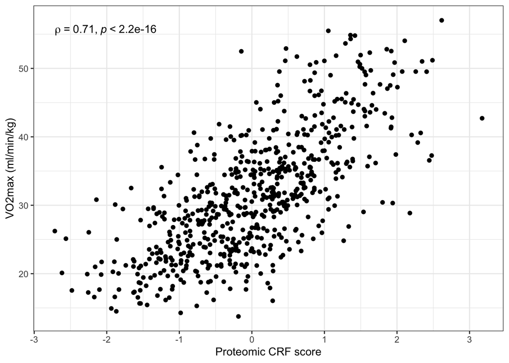

```r
part_2_df_scaled %>%
  ggplot(aes(x = proteomic_score_pre_scaled, y = B_VO2MX_B_WT18)) +
  geom_point() +
  ggpubr::stat_cor(cor.coef.name = "rho", method="spearman")  +
  labs(x = "Proteomic CRF score", y = "VO2max (ml/min/kg)")
```

post-training

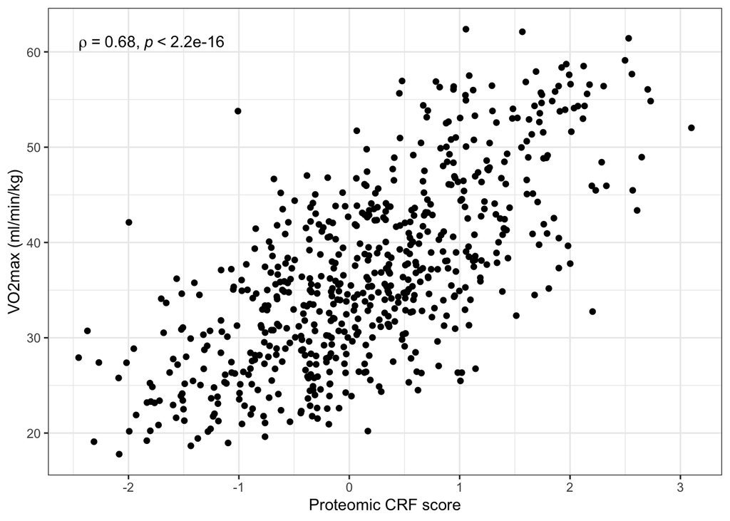

```r
part_2_df_scaled %>%
  ggplot(aes(x = proteomic_score_post_scaled, y = P_VO2MX_P_WT18)) +
  geom_point() +
  ggpubr::stat_cor(cor.coef.name = "rho", method="spearman")  +
  labs(x = "Proteomic CRF score", y = "VO2max (ml/min/kg)")
```

### 5. Sex differences in training. Please pay attention to this model as what you provided was slightly different from what I have outlined here.

###### a. post training Vo2 (P_VO2/WT_18) ~ pre training VO2 (B_VO2/WT_18) + pre training score + post training score + post training score*sex + covariates (age/race/+/-BMI)

```r
lm(P_VO2MX_P_WT18 ~ B_VO2MX_B_WT18 + proteomic_score_pre_scaled + proteomic_score_post_scaled+ AGE + proteomic_score_post_scaled*SEX + RACE, data = part_2_df_scaled) %>% tidy() %>% mutate_if(is.numeric, signif, 3) %>% kable()
```

| term | estimate | std.error | statistic | p.value |
| --- | --- | --- | --- | --- |
| (Intercept) | 9.1000 | 1.0300 | 8.790 | 0.000000 |
| B_VO2MX_B_WT18 | 0.8990 | 0.0236 | 38.100 | 0.000000 |
| proteomic_score_pre_scaled | -0.1340 | 0.2690 | -0.499 | 0.618000 |
| proteomic_score_post_scaled | 1.0800 | 0.2850 | 3.790 | 0.000163 |
| AGE | -0.0422 | 0.0114 | -3.700 | 0.000237 |
| SEXFemale | -0.2320 | 0.3080 | -0.754 | 0.451000 |
| RACECaucasian | 1.1400 | 0.2690 | 4.220 | 0.000028 |
| proteomic_score_post_scaled:SEXFemale | -0.3080 | 0.2590 | -1.190 | 0.235000 |

```r
lm(P_VO2MX_P_WT18 ~ B_VO2MX_B_WT18 + proteomic_score_pre_scaled + proteomic_score_post_scaled + AGE + proteomic_score_post_scaled*SEX + RACE + B_BMI, data = part_2_df_scaled) %>% tidy() %>% mutate_if(is.numeric, signif, 3) %>% kable()
```

| term | estimate | std.error | statistic | p.value |
| --- | --- | --- | --- | --- |
| (Intercept) | 17.6000 | 1.6500 | 10.70 | 0.00e+00 |
| B_VO2MX_B_WT18 | 0.8200 | 0.0259 | 31.70 | 0.00e+00 |
| proteomic_score_pre_scaled | -0.3340 | 0.2630 | -1.27 | 2.04e-01 |
| proteomic_score_post_scaled | 1.0900 | 0.2760 | 3.95 | 8.72e-05 |
| AGE | -0.0563 | 0.0113 | -5.00 | 8.00e-07 |
| SEXFemale | -1.3300 | 0.3430 | -3.88 | 1.17e-04 |
| RACECaucasian | 1.1400 | 0.2610 | 4.35 | 1.58e-05 |
| B_BMI | -0.1870 | 0.0288 | -6.49 | 0.00e+00 |
| proteomic_score_post_scaled:SEXFemale | -0.5420 | 0.2540 | -2.14 | 3.31e-02 |

```r
lm(P_VO2MX_P_WT18 ~ B_VO2MX_B_WT18 + proteomic_score_pre_scaled + proteomic_score_post_scaled + AGE + proteomic_score_post_scaled*SEX + RACE + B_BMI, data = part_2_df_scaled) %>% vif(type = 'predictor')   %>% kable()
```

|  | GVIF | Df | GVIF^(1/(2*Df)) | Interacts With | Other Predictors |
| --- | --- | --- | --- | --- | --- |
| B_VO2MX_B_WT18 | 4.702919 | 1 | 2.168621 | – | proteomic_score_pre_scaled, proteomic_score_post_scaled, AGE, SEX, RACE, B_BMI |
| proteomic_score_pre_scaled | 5.958926 | 1 | 2.441091 | – | B_VO2MX_B_WT18, proteomic_score_post_scaled, AGE, SEX, RACE, B_BMI |
| proteomic_score_post_scaled | 10.594516 | 3 | 1.481995 | SEX | B_VO2MX_B_WT18, proteomic_score_pre_scaled, AGE, RACE, B_BMI |
| AGE | 2.037122 | 1 | 1.427278 | – | B_VO2MX_B_WT18, proteomic_score_pre_scaled, proteomic_score_post_scaled, SEX, RACE, B_BMI |
| SEX | 10.594516 | 3 | 1.481995 | proteomic_score_post_scaled | B_VO2MX_B_WT18, proteomic_score_pre_scaled, AGE, RACE, B_BMI |
| RACE | 1.360121 | 1 | 1.166242 | – | B_VO2MX_B_WT18, proteomic_score_pre_scaled, proteomic_score_post_scaled, AGE, SEX, B_BMI |
| B_BMI | 1.989574 | 1 | 1.410522 | – | B_VO2MX_B_WT18, proteomic_score_pre_scaled, proteomic_score_post_scaled, AGE, SEX, RACE |

### 6. Looking at sex differences in the relationship between CRF protein score and VO2max

B_VO2/WT_18 ~ pre-training protein score + sex + pre-training protein score* sex + age + race + BMI

```r
lm(B_VO2MX_B_WT18 ~ proteomic_score_pre_scaled + SEX + proteomic_score_pre_scaled*SEX + AGE + RACE, data = part_2_df_scaled) %>% tidy() %>% mutate_if(is.numeric, signif, 3) %>% kable()
```

| term | estimate | std.error | statistic | p.value |
| --- | --- | --- | --- | --- |
| (Intercept) | 39.400 | 0.7790 | 50.60 | 0.00000 |
| proteomic_score_pre_scaled | 4.090 | 0.3480 | 11.80 | 0.00000 |
| SEXFemale | -4.790 | 0.4700 | -10.20 | 0.00000 |
| AGE | -0.269 | 0.0159 | -16.90 | 0.00000 |
| RACECaucasian | 5.690 | 0.3920 | 14.50 | 0.00000 |
| proteomic_score_pre_scaled:SEXFemale | -1.180 | 0.4430 | -2.65 | 0.00818 |

+ BMI

```r
lm(B_VO2MX_B_WT18 ~ proteomic_score_pre_scaled + SEX + proteomic_score_pre_scaled*SEX + AGE + RACE + B_BMI, data = part_2_df_scaled) %>% tidy() %>% mutate_if(is.numeric, signif, 3) %>% kable()
```

| term | estimate | std.error | statistic | p.value |
| --- | --- | --- | --- | --- |
| (Intercept) | 54.100 | 1.2900 | 41.90 | 0.000000 |
| proteomic_score_pre_scaled | 2.700 | 0.3240 | 8.34 | 0.000000 |
| SEXFemale | -6.790 | 0.4410 | -15.40 | 0.000000 |
| AGE | -0.247 | 0.0142 | -17.40 | 0.000000 |
| RACECaucasian | 4.460 | 0.3580 | 12.50 | 0.000000 |
| B_BMI | -0.516 | 0.0384 | -13.40 | 0.000000 |
| proteomic_score_pre_scaled:SEXFemale | -1.510 | 0.3920 | -3.86 | 0.000126 |

### Additional analysis based on Jan/09/2023.

A-1) show pre and post score correlation (based on scaling approach already performed above)

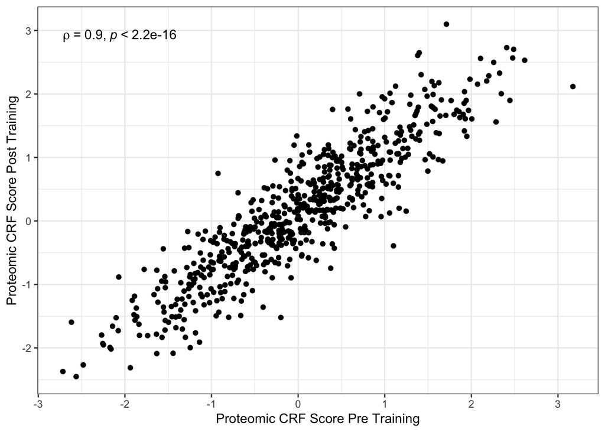

```r
protein_score_prepost_scaled %>%
  ggplot(aes(x = proteomic_score_pre_scaled, y = proteomic_score_post_scaled)) +
  geom_point() +
  # geom_smooth(method = 'lm', formula = 'y ~ x', se = F) +
  stat_cor(cor.coef.name = "rho", method = "spearman") +
  labs(x = "Proteomic CRF Score Pre Training",
       y = "Proteomic CRF Score Post Training"
       )
```

A-2) Scatter plot delta VO2 (ml/kg/min) ~ delta Proteomic CRF score (expressed in units of SD of pre-score based on this scaling approach)

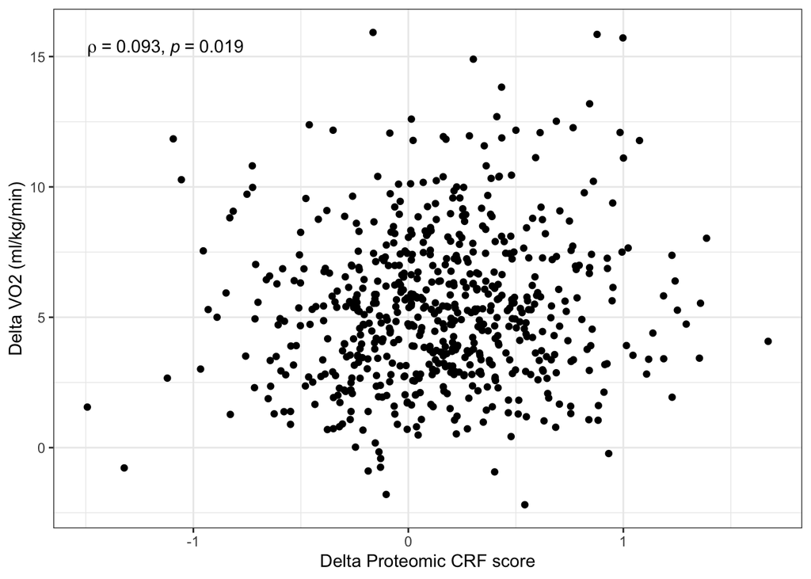

```r
part_2_df_scaled %>%
  mutate(proteomic_score_delta = proteomic_score_post_scaled - proteomic_score_pre_scaled) %>%
  ggplot(aes(x = proteomic_score_delta, y = D_VO2MX_ML_KG_MIN)) +
  geom_point() +
  stat_cor(cor.coef.name = "rho", method = "spearman") +
  labs(x = "Delta Proteomic CRF score",
       y = "Delta VO2 (ml/kg/min)")
```

```r
ggsave("report_plots/P5_delta_vo2max_delta_score_plot.pdf", device = "pdf", width = 4, height = 3)
```

A-3) calculate correlation coefficient for DELTA SCORE and BASELINE SCORE

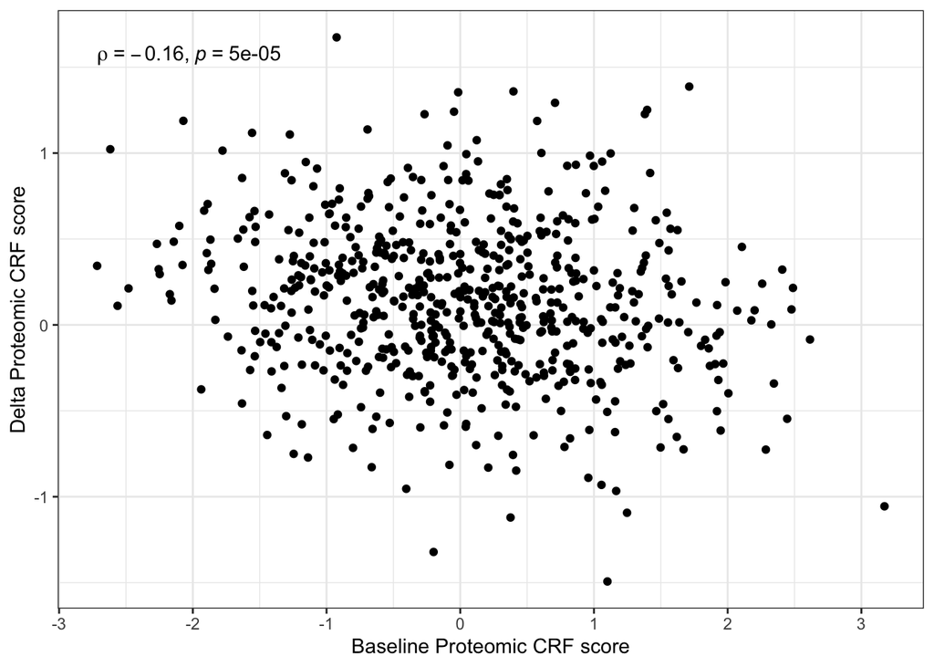

```r
part_2_df_scaled %>%
  mutate(proteomic_score_delta = proteomic_score_post_scaled - proteomic_score_pre_scaled) %>%
  ggplot(aes(x = proteomic_score_pre_scaled, y = proteomic_score_delta)) +
  geom_point() +
  stat_cor(cor.coef.name = "rho", method = "spearman") +
  labs(x = "Baseline Proteomic CRF score",
       y = "Delta Proteomic CRF score"
       )
```

A-4) calculate correlation coefficient for DELTA VO2max and BASELINE VO2max

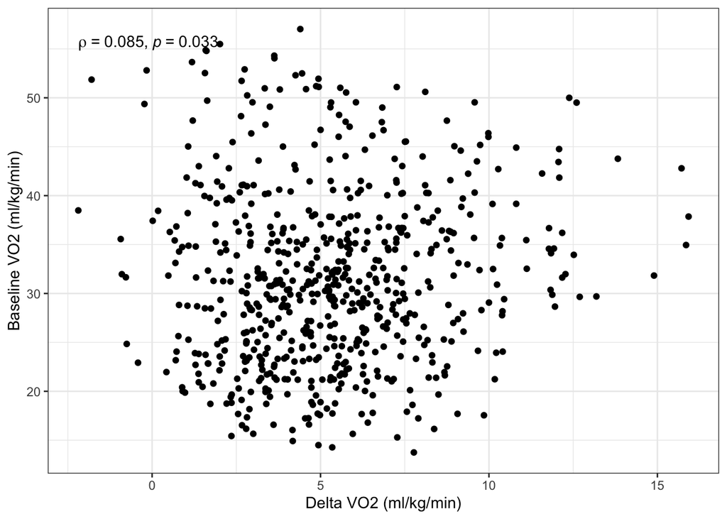

```r
part_2_df_scaled %>%
  ggplot(aes(x = D_VO2MX_ML_KG_MIN, y = B_VO2MX_B_WT18)) +
  geom_point() +
  # geom_smooth(method = "lm") +
  stat_cor(cor.coef.name = "rho", method = "spearman") +
  labs(x = "Delta VO2 (ml/kg/min)",
       y = "Baseline VO2 (ml/kg/min)")
```

A-5) calculate: DELTA VO2max (ml/kg/min) ~ DELTA Proteomic CRF Score + age + sex + race + Baseline Proteomic CRF Score

```r
ana_a5_m1 = part_2_df_scaled %>%
  mutate(proteomic_score_delta = proteomic_score_post_scaled - proteomic_score_pre_scaled) %>%
  lm(D_VO2MX_ML_KG_MIN ~ proteomic_score_delta + AGE + SEX + RACE + proteomic_score_pre_scaled, data=.)

ana_a5_m1 %>% tidy() %>% mutate_if(is.numeric, signif, 3) %>% kable()
```

| term | estimate | std.error | statistic | p.value |
| --- | --- | --- | --- | --- |
| (Intercept) | 5.2900 | 0.46700 | 11.300 | 0.00000 |
| proteomic_score_delta | 0.8130 | 0.26000 | 3.120 | 0.00187 |
| AGE | -0.0165 | 0.00965 | -1.710 | 0.08740 |
| SEXFemale | 0.1620 | 0.28600 | 0.567 | 0.57100 |
| RACECaucasian | 0.5570 | 0.23600 | 2.360 | 0.01880 |
| proteomic_score_pre_scaled | 0.4170 | 0.15800 | 2.630 | 0.00878 |

```r
ana_a5_m1 %>% vif() %>% kable()
```

|  | x |
| --- | --- |
| proteomic_score_delta | 1.079689 |
| AGE | 1.367274 |
| SEX | 1.632806 |
| RACE | 1.019676 |
| proteomic_score_pre_scaled | 1.982437 |

- BMI

```r
ana_a5_m2 = part_2_df_scaled %>%
  mutate(proteomic_score_delta = proteomic_score_post_scaled - proteomic_score_pre_scaled) %>%
  lm(D_VO2MX_ML_KG_MIN ~ proteomic_score_delta + AGE + SEX + RACE + B_BMI + proteomic_score_pre_scaled, data=.)

ana_a5_m2 %>% tidy() %>% mutate_if(is.numeric, signif, 3) %>% kable()
```

| term | estimate | std.error | statistic | p.value |
| --- | --- | --- | --- | --- |
| (Intercept) | 7.9300 | 0.89900 | 8.820 | 0.000000 |
| proteomic_score_delta | 0.7170 | 0.25900 | 2.770 | 0.005860 |
| AGE | -0.0136 | 0.00961 | -1.420 | 0.157000 |
| SEXFemale | -0.2160 | 0.30400 | -0.710 | 0.478000 |
| RACECaucasian | 0.3370 | 0.24300 | 1.390 | 0.165000 |
| B_BMI | -0.0899 | 0.02620 | -3.430 | 0.000648 |
| proteomic_score_pre_scaled | 0.1270 | 0.17800 | 0.709 | 0.478000 |

```r
ana_a5_m2 %>% vif() %>% kable()
```

|  | x |
| --- | --- |
| proteomic_score_delta | 1.092243 |
| AGE | 1.377989 |
| SEX | 1.880048 |
| RACE | 1.095752 |
| B_BMI | 1.536560 |
| proteomic_score_pre_scaled | 2.557035 |

A-6) calculate: DELTA VO2max (ml/kg/min) ~ Delta Proteomic CRF Score + age + sex + race + Baseline Proteomic CRF Score + baseline VO2max (ml/kg/min)

```r
ana_a6_m1 = part_2_df_scaled %>%
  mutate(proteomic_score_delta = proteomic_score_post_scaled - proteomic_score_pre_scaled) %>%
  lm(D_VO2MX_ML_KG_MIN ~ proteomic_score_delta + AGE + SEX + RACE + proteomic_score_pre_scaled + B_VO2MX_B_WT18, data=.)

ana_a6_m1 %>% tidy() %>% mutate_if(is.numeric, signif, 3) %>% kable()
```

| term | estimate | std.error | statistic | p.value |
| --- | --- | --- | --- | --- |
| (Intercept) | 9.1700 | 1.0300 | 8.870 | 0.00e+00 |
| proteomic_score_delta | 0.9380 | 0.2580 | 3.630 | 3.07e-04 |
| AGE | -0.0428 | 0.0114 | -3.750 | 1.90e-04 |
| SEXFemale | -0.2990 | 0.3030 | -0.986 | 3.25e-01 |
| RACECaucasian | 1.1200 | 0.2690 | 4.160 | 3.62e-05 |
| proteomic_score_pre_scaled | 0.7800 | 0.1790 | 4.360 | 1.50e-05 |
| B_VO2MX_B_WT18 | -0.0986 | 0.0235 | -4.200 | 3.09e-05 |

```r
ana_a6_m1 %>% vif() %>% kable()
```

|  | x |
| --- | --- |
| proteomic_score_delta | 1.094370 |
| AGE | 1.957260 |
| SEX | 1.879796 |
| RACE | 1.356042 |
| proteomic_score_pre_scaled | 2.589654 |
| B_VO2MX_B_WT18 | 3.633260 |

- BMI

```r
ana_a6_m2 = part_2_df_scaled %>%
  mutate(proteomic_score_delta = proteomic_score_post_scaled - proteomic_score_pre_scaled) %>%
  lm(D_VO2MX_ML_KG_MIN ~ proteomic_score_delta + AGE + SEX + RACE + B_BMI + proteomic_score_pre_scaled + B_VO2MX_B_WT18, data=.)

ana_a6_m2 %>% tidy() %>% mutate_if(is.numeric, signif, 3) %>% kable()
```

| term | estimate | std.error | statistic | p.value |
| --- | --- | --- | --- | --- |
| (Intercept) | 17.3000 | 1.6500 | 10.50 | 0.00e+00 |
| proteomic_score_delta | 0.8440 | 0.2510 | 3.35 | 8.45e-04 |
| AGE | -0.0567 | 0.0113 | -5.02 | 7.00e-07 |
| SEXFemale | -1.3900 | 0.3430 | -4.07 | 5.41e-05 |
| RACECaucasian | 1.1100 | 0.2610 | 4.23 | 2.69e-05 |
| B_BMI | -0.1780 | 0.0285 | -6.23 | 0.00e+00 |
| proteomic_score_pre_scaled | 0.4770 | 0.1800 | 2.65 | 8.31e-03 |
| B_VO2MX_B_WT18 | -0.1720 | 0.0257 | -6.71 | 0.00e+00 |

```r
ana_a6_m2 %>% vif() %>% kable()
```

|  | x |
| --- | --- |
| proteomic_score_delta | 1.098388 |
| AGE | 2.036564 |
| SEX | 2.548478 |
| RACE | 1.356142 |
| B_BMI | 1.949533 |
| proteomic_score_pre_scaled | 2.792023 |
| B_VO2MX_B_WT18 | 4.609751 |

A-7) calculate: DELTA VO2max (ml/kg/min) ~ Delta Proteomic CRF Score + age + sex + race + Baseline Proteomic CRF Score + baseline VO2max (ml/kg/min) + Delta Proteomic CRF Score * sex

```r
ana_a7_m1 = part_2_df_scaled %>%
  mutate(proteomic_score_delta = proteomic_score_post_scaled - proteomic_score_pre_scaled) %>%
  lm(D_VO2MX_ML_KG_MIN ~ proteomic_score_delta + SEX + proteomic_score_delta*SEX + AGE+ RACE + proteomic_score_pre_scaled + B_VO2MX_B_WT18, data=.)

ana_a7_m1 %>% tidy() %>% mutate_if(is.numeric, signif, 3) %>% kable()
```

| term | estimate | std.error | statistic | p.value |
| --- | --- | --- | --- | --- |
| (Intercept) | 9.1500 | 1.0400 | 8.830 | 0.00e+00 |
| proteomic_score_delta | 1.0100 | 0.3630 | 2.790 | 5.37e-03 |
| SEXFemale | -0.2780 | 0.3110 | -0.894 | 3.72e-01 |
| AGE | -0.0426 | 0.0114 | -3.730 | 2.13e-04 |
| RACECaucasian | 1.1100 | 0.2700 | 4.130 | 4.15e-05 |
| proteomic_score_pre_scaled | 0.7780 | 0.1790 | 4.350 | 1.61e-05 |
| B_VO2MX_B_WT18 | -0.0985 | 0.0235 | -4.190 | 3.22e-05 |
| proteomic_score_delta:SEXFemale | -0.1480 | 0.4980 | -0.298 | 7.66e-01 |

```r
ana_a7_m1 %>% vif() %>% kable()
```

|  | x |
| --- | --- |
| proteomic_score_delta | 2.155606 |
| SEX | 1.978820 |
| AGE | 1.964928 |
| RACE | 1.361963 |
| proteomic_score_pre_scaled | 2.592426 |
| B_VO2MX_B_WT18 | 3.634433 |
| proteomic_score_delta:SEX | 2.181518 |

+ BMI

```r
ana_a7_m2 = part_2_df_scaled %>%
  mutate(proteomic_score_delta = proteomic_score_post_scaled - proteomic_score_pre_scaled) %>%
  lm(D_VO2MX_ML_KG_MIN ~ proteomic_score_delta + SEX + proteomic_score_delta*SEX + AGE+ RACE + B_BMI+ proteomic_score_pre_scaled + B_VO2MX_B_WT18, data=.)

ana_a7_m2 %>% tidy() %>% mutate_if(is.numeric, signif, 3) %>% kable()
```

| term | estimate | std.error | statistic | p.value |
| --- | --- | --- | --- | --- |
| (Intercept) | 17.3000 | 1.6500 | 10.500 | 0.00e+00 |
| proteomic_score_delta | 0.9650 | 0.3530 | 2.740 | 6.37e-03 |
| SEXFemale | -1.3600 | 0.3480 | -3.910 | 1.03e-04 |
| AGE | -0.0564 | 0.0113 | -4.980 | 8.00e-07 |
| RACECaucasian | 1.1000 | 0.2620 | 4.190 | 3.25e-05 |
| B_BMI | -0.1780 | 0.0286 | -6.240 | 0.00e+00 |
| proteomic_score_pre_scaled | 0.4740 | 0.1810 | 2.620 | 8.89e-03 |
| B_VO2MX_B_WT18 | -0.1720 | 0.0257 | -6.700 | 0.00e+00 |
| proteomic_score_delta:SEXFemale | -0.2390 | 0.4840 | -0.493 | 6.22e-01 |

```r
ana_a7_m2 %>% vif() %>% kable()
```

|  | x |
| --- | --- |
| proteomic_score_delta | 2.156672 |
| SEX | 2.632811 |
| AGE | 2.042836 |
| RACE | 1.362114 |
| B_BMI | 1.951272 |
| proteomic_score_pre_scaled | 2.796394 |
| B_VO2MX_B_WT18 | 4.609774 |
| proteomic_score_delta:SEX | 2.183464 |